# Approximate Bayesian Computation

```python
import numpy as np
import matplotlib.pyplot as plt

import corner
np.random.seed(3)
```

# Example 0

Let's return to the example from a few weeks ago

> We point our telescope to observe the light from a single star with true flux $F_{\rm true}$, which remains constant with time. We will ignore any systematic errors. We perform $N$ measurements with our telescope, where the $i^{\rm th}$ measurement report an observed flux $F_i$ with uncertainty/error $e_i$.

Start by generating a synthetic observation

```python
F_true = 1000
F_obs = np.random.poisson(lam=F_true)
```

We can also write down the simulation of the **data generation process**. In this case this is trivial because we know exact data generation process.

```python
def simulation(F_true):
    return np.random.poisson(lam=F_true)
```

ABC first involves repeating two steps

1. sample the prior: $\theta'\sim p(\theta)$
2. run simulation: $\mathcal{D}' \sim F(\theta')$

For our prior, lets use $$p(\theta) = \mathcal{N}(1002, 4)$$

```python
def sample_prior():
    # sample prior
    return 1002. + 4. * np.random.normal()
```

Let's repeat the process `Nsample = 100000` times

```python
Nsample = 100000

samples = np.zeros((Nsample, 2))
for i in range(Nsample):
    theta_p = sample_prior()
    data_p = simulation(theta_p)
    samples[i,:] = np.array([theta_p, data_p])
```

Now we have a bunch of $\{(\theta', \mathcal{D}')\}$ samples drawn from the joint distribution $p(\theta, \mathcal{D})$.

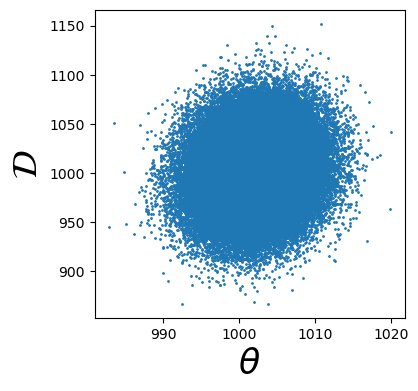

```python
plt.figure(figsize=(4,4))
plt.scatter(samples[:,0], samples[:,1], s=1)
plt.xlabel(r'$\theta$', fontsize=25)
plt.ylabel(r'$\mathcal{D}$', fontsize=25); plt.show()
```

Now to obtain the **posterior** from these samples, ABC approximates: $$p(\theta\,|\,\mathcal{D}_{\rm obs}) \approx p(\theta\,|\,\mathcal{D} \approx \mathcal{D}_{\rm obs})$$

We'll define

```python
close_enough = np.abs(samples[:,1] - F_obs) < 1
print('%i simulations have D approx D_obs' % np.sum(close_enough))
```

```
1224 simulations have D pprox D_obs
```

We can visualize the $\mathcal{D} \approx \mathcal{D}_{\rm obs}$ in the $p(\theta, \mathcal{D})$ distribution

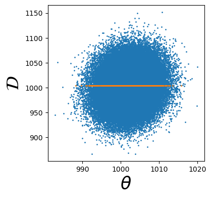

```python
plt.figure(figsize=(4,4))
plt.scatter(samples[:,0], samples[:,1], s=1)
plt.scatter(samples[:,0][close_enough], samples[:,1][close_enough], s=1, c='C1')
plt.xlabel(r'$\theta$', fontsize=25)
plt.ylabel(r'$\mathcal{D}$', fontsize=25); plt.show()
```

More importantly, we can examine their $\theta$ distribution to estimate the posterior

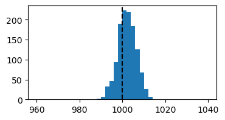

```python
plt.figure(figsize=(4,2))
plt.hist(samples[:,0][close_enough], range=(960, 1040), bins=40)
plt.axvline(F_true, color='k', linestyle='--')
```

Looks pretty reasonable!

# Example 1

Now that was a very simple 1D example. Lets consider a slightly more interesting example: our favorite, fitting a line to some data.

Here's the same data and setup from the MCMC example:

```python
a_true, b_true = 0, 1.75
x = np.array([1,1.5,2,2.5])
y = np.array([1.87640523, 2.59001572, 3.4978738 , 4.47408932])
yerr = 0.1
```

[output not shown]

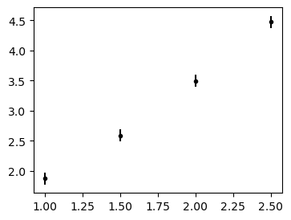

```python
plt.figure(figsize=(4,3))
plt.errorbar(x, y, yerr=yerr, fmt='.k')
```

Same as before, lets set up the **simulation approximating the data generation process** and choose our **prior**

```python
def simulation(theta):
    a, b = theta
    noise = yerr * np.random.normal(size=len(x))
    return a + b * x + noise

def sample_prior():
    # sample a and b from uniform prior
    _a = -0.5 + np.random.uniform()
    _b = 10*np.random.uniform()
    return [_a, _b]
```

Let's generate a bunch of samples from $p(\theta, \mathcal{D})$

```python
Nsample = 500000

samples = np.zeros((Nsample, 6))
for i in range(Nsample):
    theta_p = sample_prior()
    data_p = simulation(theta_p)
    samples[i,:] = np.concatenate([theta_p, data_p])
```

Now this is harder to visualize since $\theta$ is 2D and $\mathcal{D}$ is 4D --- $p(\theta, \mathcal{D})$ is a 6D distribution.

Regardless of dimensions, the rest of the procedure for ABC remains the same:

1. keep only samples with $\mathcal{D} \approx \mathcal{D}_{\rm obs}$
2. examine the distribution of $\theta$

Since $\mathcal{D}$ is 4D, we will use euclidean distance $\rho(\mathcal{D}, \mathcal{D}') < \epsilon$ for (1).

```python
rho = np.sqrt(np.sum((samples[:,2:] - y[None, :])**2, axis=1))
```

```python
epsilon = 0.5
print('reject %f percent of simulations' % (100.*(1-np.mean(rho < epsilon))))
```

```
reject 97.790200 percent of simulations
```

Now lets look at the $\theta$ distribution of the accepted samples --- i.e. the posterior estimate.

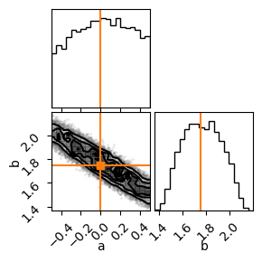

```python
fig = plt.figure(figsize=(3,3))
_ = corner.corner(samples[:,:2][rho < epsilon], labels=['a', 'b'], fig=fig)
corner.overplot_lines(fig, [a_true, b_true], color="C1")
corner.overplot_points(fig, np.array([a_true, b_true])[None], marker="s", color="C1")
```

You may have noticed that the posterior estimate is significantly broader than the posterior from MCMC from earlier. That's the "approximate" part of ABC and a consequence of relaxing $\mathcal{D} = \mathcal{D}'$ to $\rho(\mathcal{D}, \mathcal{D}') < \epsilon$.

Now if we reduce $\epsilon$, we'll get closer to the true posterior

```python
epsilon = 0.2
print('reject %f percent of simulations' % (100.*(1-np.mean(rho < epsilon))))
```

```
reject 99.807200 percent of simulations
```

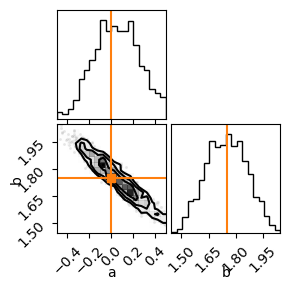

```python
fig = plt.figure(figsize=(3,3))
_ = corner.corner(samples[:,:2][rho < epsilon], labels=['a', 'b'], fig=fig)
corner.overplot_lines(fig, [a_true, b_true], color="C1"); corner.overplot_points(fig, np.array([a_true, b_true])[None], marker="s", color="C1"); plt.show()
```

Indeed we are closer to the true posterior. But there are fewer samples and the posterior estimate is noisier.

As you decrease $\epsilon$, you get closer to the true posterior but you also need to sample $p(\theta, \mathcal{D})$ more times.

## some **caveats** of ABC

$$p(\theta\,|\,\mathcal{D}_{\rm obs}) \approx p(\theta\,|\,\rho(\mathcal{D}_{\rm obs}, \mathcal{D}) < \epsilon)$$

- only accurate for arbitrarily small $\epsilon$
- smaller $\epsilon$ means more simulations are rejected (less efficient)

## ABC with more efficient sampling (e.g. Population Monte Carlo)

```
# initialize
t = 0
for i in 1 ... N:
    while rho(D*, D_obs) > epsilon_t:
        draw theta* ~ p(theta)
        simulate D* = F(theta*)
    theta^i_t = theta*
    w^i_t = 1/N

for t = 1 ... T:
    for i in 1 ... N:
        while rho(D*, D_obs) > epsilon_t:
            draw theta* ~ from {theta_t-1} with probability {w_t-1}
            pertrub theta* <- K(theta*, Sigma)
            simulate D* = F(theta*)

        theta^i_t = theta*
        # importance weights to impose the prior
        w^i_t = p(theta^i_t) / Sum_j w^j_t-1 K
```

# unit summary

- ABC enables Bayesian inference even when we don't have access to the explicit likelihood --- as long as we have a simulation that approximates the data generation process
- ABC is simple to implement. Once you have the simulator and prior, ABC can be implemented in just a few lines of code!
- ABC often requires approximating $\mathcal{D} = \mathcal{D}_{\rm obs}$. This impacts the accuracy of the posterior and efficiency